# Решение домашки №3

```r
library(tidyr)
library(naniar)
library(ggplot2)
library(stringr)
library(dplyr)
```

В пакете `tidyr` есть замечательный набор данных `us_rent_income`, который мы будем использовать. В нем собраны данные об арендной плате для каждого штата США. Более подробно о нем можно узнать с помощью команды `?us_rent_income` Опишем каждую переменную.

- `GEOID` – номер штата
- `NAME` – название штата
- `variable` – название показателя
  - `income` – медианный годовой доход людей
  - `rent` – медианная рента
- `moe` – 90% погрешность показателей (например, если `income` равно 100, а его `moe` 10, то 90% значений лежит в интервале от 90 до 110)

```r
glimpse(us_rent_income)
```

```
## Observations: 104
## Variables: 5
## $ GEOID    <chr> "01", "01", "02", "02", "04", "04", "05", "05", "06", "…
## $ NAME     <chr> "Alabama", "Alabama", "Alaska", "Alaska", "Arizona", "A…
## $ variable <chr> "income", "rent", "income", "rent", "income", "rent", "…
## $ estimate <dbl> 24476, 747, 32940, 1200, 27517, 972, 23789, 709, 29454,…
## $ moe      <dbl> 136, 3, 508, 13, 148, 4, 165, 5, 109, 3, 109, 5, 195, 5…
```

### Задание 1 (30 баллов)

Сейчас переменная `variable` содержит в себе еще две переменные. Из-за этого у нас по 2 наблюдения на каждый штат. Нужно преобразовать данные к следующему виду.

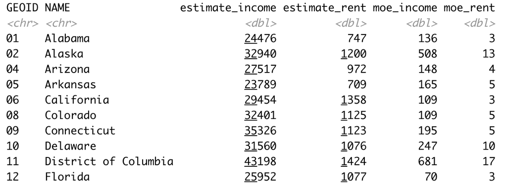

**Важно!** Колонки с показателями должны иметь числовой формат.

Эту задачу можно решить 2 способами. Первый мы сможем реализовать с теми знаниями, которые у нас есть. Второй очень простой, но надо изучить функцию `pivot_wider` из пакета `tidyr`. Она работает так же как и функция `spread`, но у нее есть свой большой плюс. Когда вы будете решать задачу, объясните проблему, из-за которой вы не смогли сделать это задание с помощью только одной функции `spread`.

```r
rent <- us_rent_income %>%
          pivot_wider(names_from = variable,
                      values_from = c('estimate', 'moe'))
```

```r
rent <- us_rent_income %>%
          unite(common, estimate, moe, sep = '-') %>%
          spread(variable, common) %>%
          separate(income, into = c('income', 'income_error'), convert = T) %>%
          separate(rent, into = c('rent', 'rent_error'), convert = T)

glimpse(rent)
```

```
## Observations: 52
## Variables: 6
## $ GEOID        <chr> "01", "02", "04", "05", "06", "08", "09", "10", "11…
## $ NAME         <chr> "Alabama", "Alaska", "Arizona", "Arkansas", "Califo…
## $ income       <int> 24476, 32940, 27517, 23789, 29454, 32401, 35326, 31…
## $ income_error <int> 136, 508, 148, 165, 109, 109, 195, 247, 681, 70, 10…
## $ rent         <int> 747, 1200, 972, 709, 1358, 1125, 1123, 1076, 1424, …
## $ rent_error   <int> 3, 13, 4, 5, 3, 5, 5, 10, 17, 3, 3, 18, 7, 3, 3, 4,…
```

### Задание 2 (10 баллов)

Переменная `GEOID` имеет строковый тип, нужно привести его к числовому.

*Hints:*

- Аналогично номеру из семинара, где нужно было убрать X из X1.
- У вас возникнет проблема с 0. Вам нужно убрать только нули, которые **идут в начале строки**.

```r
rent <- rent %>%
          mutate(GEOID = str_replace(GEOID, '^0', ''),
                 GEOID = as.numeric(GEOID))
```

### Задание 3 (20 баллов)

- Нарисуйте гистограммы распределений для переменных `income` и `rent`.
- Подберите адекватный по вашему мнению параметр `bins`.
- Проведите вертикальную линию, которая будет показывать среднее значение.
- Подпишите оси.

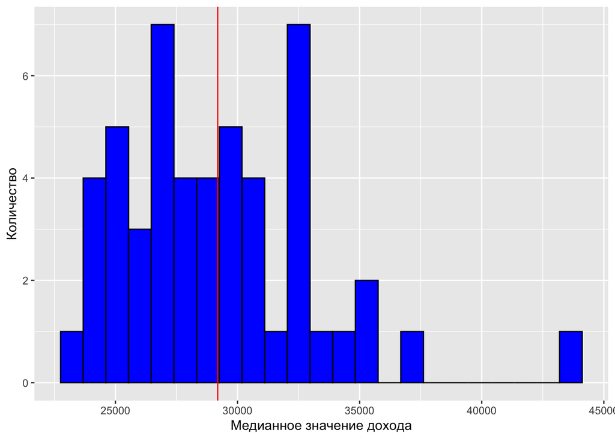

```r
MEAN_income <- mean(rent$income, na.rm = T)
ggplot(rent, aes(income)) +
  geom_histogram(bins = 23, col='black', fill='blue') +
  geom_vline(xintercept = MEAN_income, col='red') +
  ylab('Количество') +
  xlab('Медианное значение дохода')
```

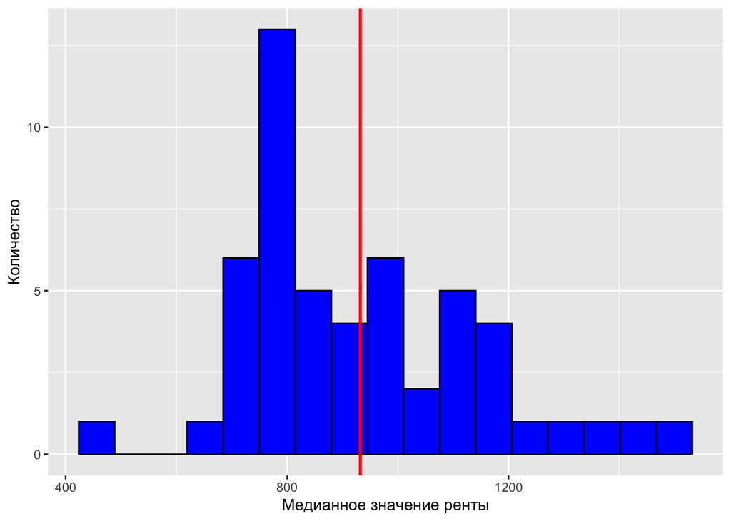

```r
MEAN_rent <- mean(rent$rent, na.rm = T)
ggplot(rent, aes(rent)) +
  geom_histogram(bins = 17, col='black', fill='blue') +
  geom_vline(xintercept = MEAN_rent, col='red', size=1) +
  ylab('Количество') +
  xlab('Медианное значение ренты')
```

### Задание 4 (20 баллов)

Есть ли пропущенные значения? Нарисуйте график, который показывает количество пропущенных значений в вашем датасете. Можно ли заменить значения пропущенных переменных их средними? Если да, то замените. Если нет, то просто выкиньте эти переменные.

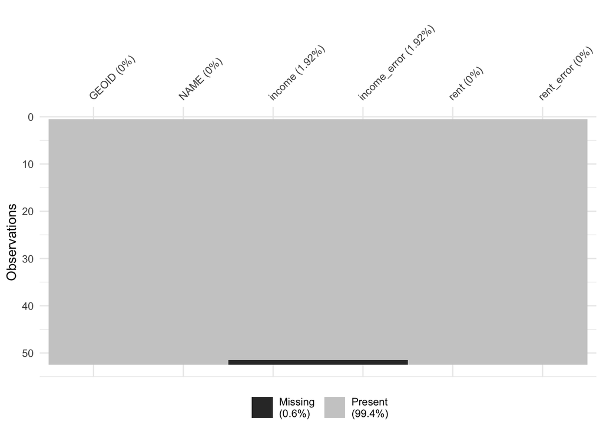

```r
vis_miss(rent)
```

При работе с пропущенными значениями нет какого-то одного правильного решения. Вы можете поступать так, как считаете нужным. Считать Пуэрто-Рико частью США или нет, завивисит от вашего исследования.

**Первый способ**

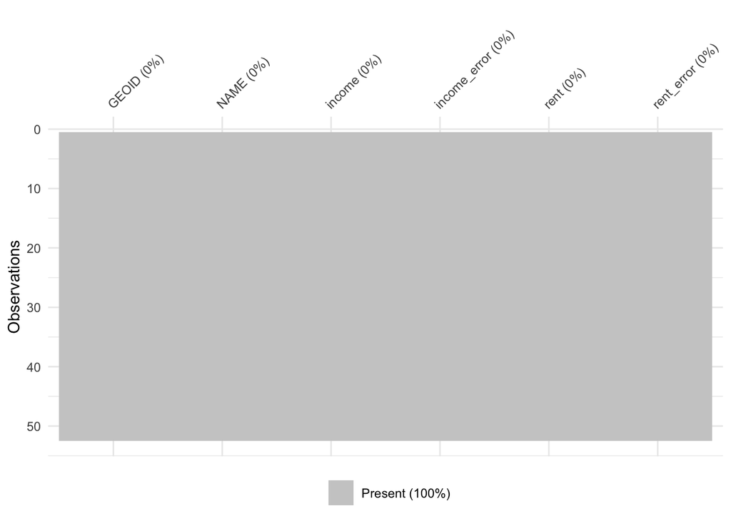

```r
rent_mean <- rent %>%
              impute_mean_at(c('income', 'income_error'))
vis_miss(rent_mean)
```

**Второй способ**

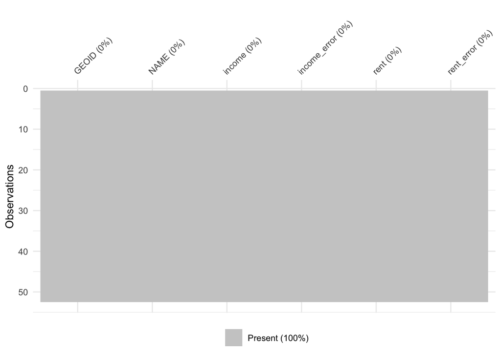

```r
rent_drop <- rent %>%
              drop_na()
vis_miss(rent_mean)
```

### Задание 5 (20 баллов)

Нарисуйте график рассеяния между доходом (`income`) и арендной платой (`rent`). Есть ли какая-то зависимость? Наложите на график линию линейной регрессии с помощью слоя `geom_smooth(method='lm')`. Подпишите оси и дайте название вашему графику.

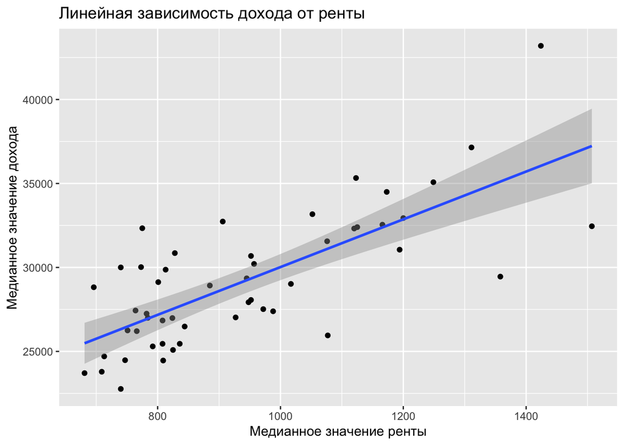

```r
ggplot(rent_drop, aes(rent, income)) +
  geom_point() +
  geom_smooth(method='lm') +
  xlab('Медианное значение ренты') +
  ylab('Медианное значение дохода') +
  labs(title = 'Линейная зависимость дохода от ренты')
```